# The ProfoundData R-package

Ramiro Silveyra Gonzalez, Christopher Reyer, Mats Mahnken, Florian Hartig

2020-05-04

Abstract

This vignette provides an overview of the Profound data R package. For an overview about the database, see the separate vignette PROFOUNDdatabase.

# ProfoundData R-package: using the PROFOUND database from R

The ProfoundData package serves as interface to access the PROFOUND database. Three main functions are included to achieve this goal: a browseData function for exploring the database, a getData function for downloading data from the database and a plotData function to quickly inspect any variable of the datasets.

The functions allow to retrieve only data from one site and one dataset at a time. For downloading data of more than one dataset or of more than one site, the function should be called as many times as the number of desired sites or datasets. Additionally, flags and other parameters can be passed to the functions. The package also includes utilities functions to do tasks such as inspecting the data or writing NetCDF files.

To see the suggested ciation for the package, run

```r
library(ProfoundData)
citation("ProfoundData")
```

```
##
##
##   Reyer, C. (2019). The PROFOUND Database for evaluating vegetation
##   models and simulating climate impacts on forest stands. Submitted to
##   Earth System Science Data.
##
##   Reyer, C., Silveyra Gonzalez, R., Dolos, K., Hartig, F., Hauf, Y.,
##   Noack, M., … Frieler, K. (2020). The PROFOUND database for evaluating
##   vegetation models and simulating climate impacts on forests [Data
##   set]. https://doi.org/10.5880/PIK.2020.006
##
## To see these entries in BibTeX format, use 'print(<citation>,
## bibtex=TRUE)', 'toBibtex(.)', or set
## 'options(citation.bibtex.max=999)'.
```

# First Steps

## Database download

The Profound database is provided in SQLite and can be downloaded either by hand at http://doi.org/10.5880/PIK.2020.006 or via

```r
sqlfile = downloadDatabase()
```

Per default, the database is downloaded into the current working directory, but you can specify another location in the function. The function returns the current database location, which can be passed on to the setDB function (see below).

## Database connection

For using a locally stored database with the ProfoundData package, the first step is to call *setDB*. The function requires a **valid absolute path to the PROFOUND database**.

```r
myDB <- path.expand("C:/Users/mahnken/Documents/OTHER/ProfoundDataTesting/final_v03/ProfoundData.sqlite")
setDB(myDB)
```

To check the database connection you can use *getDB*, which returns the database path and also informs about the database version.

```r
getDB()
```

```
## Database version is 0.3
```

```
## [1] "/Users/florian/temp/ProfoundData.sqlite"
```

# Exploring the database

## The browseData function

The browseData function allows to see what data is included in the database and for what sites the data is available.

```r
overview <- browseData()
```

```r
knitr::kable(overview, align = "l")
```

| site_id | site | SITES | TREE | STAND | SOIL | CLIMATE_LOCAL | CLIMATE_ISIMIP2B | CLIMATE_ISIMIP2BLBC | CLIMATE_ISIMIP2A | CLIMATE_ISIMIPFT | METEOROLOGICAL | FLUX | ATMOSPHERICHEATCONDUCTION | SOILTS | NDEPOSITION_EMEP | NDEPOSITION_ISIMIP2B | CO2_ISIMIP | MODIS_MOD09A1 | MODIS_MOD15A2 | MODIS_MOD11A2 | MODIS_MOD13Q1 | MODIS_MOD17A2 | MODIS |
| --- | --- | --- | --- | --- | --- | --- | --- | --- | --- | --- | --- | --- | --- | --- | --- | --- | --- | --- | --- | --- | --- | --- | --- |
| 3 | bily_kriz | 1 | 1 | 1 | 1 | 1 | 1 | 1 | 1 | 1 | 1 | 1 | 1 | 1 | 1 | 1 | 1 | 1 | 1 | 1 | 1 | 1 | 1 |
| 5 | collelongo | 1 | 1 | 1 | 1 | 1 | 1 | 1 | 1 | 1 | 1 | 1 | 1 | 1 | 1 | 1 | 1 | 1 | 1 | 1 | 1 | 1 | 1 |
| 12 | hyytiala | 1 | 1 | 1 | 1 | 1 | 1 | 1 | 1 | 1 | 1 | 1 | 1 | 1 | 1 | 1 | 1 | 1 | 1 | 1 | 1 | 1 | 1 |
| 13 | kroof | 1 | 1 | 1 | 1 | 1 | 1 | 1 | 1 | 1 | 0 | 0 | 0 | 0 | 1 | 1 | 1 | 1 | 1 | 1 | 1 | 1 | 1 |
| 14 | le_bray | 1 | 0 | 1 | 1 | 1 | 1 | 1 | 1 | 1 | 1 | 1 | 1 | 1 | 1 | 1 | 1 | 1 | 1 | 1 | 1 | 1 | 1 |
| 16 | peitz | 1 | 1 | 1 | 1 | 1 | 1 | 1 | 1 | 1 | 0 | 0 | 0 | 0 | 1 | 1 | 1 | 1 | 1 | 1 | 1 | 1 | 1 |
| 20 | solling_beech | 1 | 1 | 1 | 1 | 1 | 1 | 1 | 1 | 1 | 0 | 0 | 0 | 0 | 1 | 1 | 1 | 1 | 1 | 1 | 1 | 1 | 1 |
| 21 | soro | 1 | 1 | 1 | 1 | 1 | 1 | 1 | 1 | 1 | 1 | 1 | 1 | 1 | 1 | 1 | 1 | 1 | 1 | 1 | 1 | 1 | 1 |
| 25 | solling_spruce | 1 | 1 | 1 | 1 | 1 | 1 | 1 | 1 | 1 | 0 | 0 | 0 | 0 | 1 | 1 | 1 | 1 | 1 | 1 | 1 | 1 | 1 |

Hint: If you set *collapse* to FALSE, you will get the full version of the overview table.

```r
overview <- browseData(collapse = F)
```

Besides returning the overview, browseData allows to check:

- available datasets

```r
tables <- browseData(dataset = "DATASETS")
```

- available variables for a given dataset

```r
variables <- browseData(dataset = "CLIMATE_LOCAL", variables = T)
```

- available sites for a given dataset

```r
available <- browseData(dataset = "CLIMATE_LOCAL")
```

- available datasets for a given site

```r
available <- browseData(site ="le_bray")
```

- whether a dataset is available for a specific site

```r
available <- browseData(site ="le_bray", dataset = "CLIMATE_LOCAL")
```

- version history

```r
version <- browseData(dataset = "VERSION")
```

- metadata

```r
metadata <- browseData(dataset = "METADATA_CLIMATE_LOCAL")
```

Hint: You can also pass a site to check the metadata of a specific site.

```r
metadata <- browseData(dataset = "METADATA_TREE", site = "solling_spruce")
```

- source

```r
source <- browseData(dataset = "SOURCE")
```

Hint: You can also pass a site to check the source of a specific site.

```r
source <- browseData(dataset = "SOURCE", site = "solling_spruce")
```

- policy

```r
source <- browseData(dataset = "POLICY")
```

Hint: You can also pass a site to check the policy of a specific site.

```r
policy <- browseData(dataset = "POLICY", site = "solling_spruce")
```

## The summarizeData function

### Data overviews of the available data

The *summarizeData* function allows to obtain data summaries and overviews of the data depending on **mode**. If you choose the mode overview, *summarizeData* will return a data frame with the years and number of observations, the first and last value, and the min and max value, as in the example below.

```r
data <-summarizeData(dataset = "CLIMATE_LOCAL", site = "bily_kriz", mode = "overview")
```

```r
kable(data, row.names = F)
```

| site | site_id | variable | first | last | min | max | mean | year_first | year_last | obs |
| --- | --- | --- | --- | --- | --- | --- | --- | --- | --- | --- |
| bily_kriz | 3 | tmax_degC | 1.353014e+01 | 1.053710e+01 | 9.310364e+00 | 1.353014e+01 | 1.150140e+01 | 2000 | 2008 | 9 |
| bily_kriz | 3 | tmean_degC | 8.536865e+00 | 7.484678e+00 | 5.930202e+00 | 8.536865e+00 | 7.356880e+00 | 2000 | 2008 | 9 |
| bily_kriz | 3 | tmin_degC | 4.102271e+00 | 4.652052e+00 | 2.349707e+00 | 4.652052e+00 | 3.801032e+00 | 2000 | 2008 | 9 |
| bily_kriz | 3 | p_mm | 1.490324e+03 | 1.167563e+03 | 1.004007e+03 | 1.750245e+03 | 1.434560e+03 | 2000 | 2008 | 9 |
| bily_kriz | 3 | relhum_percent | 7.993809e+01 | 8.380125e+01 | 7.276064e+01 | 8.884459e+01 | 8.198789e+01 | 2000 | 2008 | 9 |
| bily_kriz | 3 | airpress_hPa | 9.127901e+02 | 9.131897e+02 | 9.117648e+02 | 9.144979e+02 | 9.131942e+02 | 2000 | 2008 | 9 |
| bily_kriz | 3 | rad_Jcm2 | 3.706045e+05 | 3.871684e+05 | 3.418508e+05 | 4.053810e+05 | 3.787749e+05 | 2000 | 2008 | 9 |
| bily_kriz | 3 | wind_ms | 2.350770e+00 | 2.404200e+00 | 1.945468e+00 | 2.474911e+00 | 2.188664e+00 | 2000 | 2008 | 9 |

The overview tables for ISIMIP datasets contain more fields, namely forcing datasets and/or forcing conditions.

```r
data <-summarizeData(dataset = "CLIMATE_ISIMIP2B", site = "bily_kriz", mode = "overview")
```

```r
kable(data, row.names = F)
```

| site | site_id | forcingDataset | forcingCondition | variable | first | last | min | max | mean | year_first | year_last | obs |
| --- | --- | --- | --- | --- | --- | --- | --- | --- | --- | --- | --- | --- |
| bily_kriz | 3 | GFDLESM2M | historical | tmax_degC | 1.006887e+01 | 1.147109e+01 | 8.685277e+00 | 1.525831e+01 | 1.154169e+01 | 1861 | 2005 | 145 |
| bily_kriz | 3 | GFDLESM2M | historical | tmean_degC | 5.878167e+00 | 6.749036e+00 | 4.454744e+00 | 9.924510e+00 | 6.930977e+00 | 1861 | 2005 | 145 |
| bily_kriz | 3 | GFDLESM2M | historical | tmin_degC | 1.692771e+00 | 1.964804e+00 | 1.069216e-01 | 4.430233e+00 | 2.223197e+00 | 1861 | 2005 | 145 |
| bily_kriz | 3 | GFDLESM2M | historical | p_mm | 9.766867e+02 | 1.125590e+03 | 6.073860e+02 | 1.311257e+03 | 9.683358e+02 | 1861 | 2005 | 145 |
| bily_kriz | 3 | GFDLESM2M | historical | relhum_percent | 7.694075e+01 | 7.747906e+01 | 6.644276e+01 | 7.905318e+01 | 7.428709e+01 | 1861 | 2005 | 145 |
| bily_kriz | 3 | GFDLESM2M | historical | airpress_hPa | 9.490722e+02 | 9.495864e+02 | 9.468872e+02 | 9.533306e+02 | 9.498743e+02 | 1861 | 2005 | 145 |
| bily_kriz | 3 | GFDLESM2M | historical | rad_Jcm2 | 3.780155e+05 | 3.823430e+05 | 3.557333e+05 | 4.346502e+05 | 3.911453e+05 | 1861 | 2005 | 145 |
| bily_kriz | 3 | GFDLESM2M | historical | wind_ms | 2.800383e+00 | 3.286238e+00 | 2.800383e+00 | 3.490822e+00 | 3.217614e+00 | 1861 | 2005 | 145 |
| bily_kriz | 3 | GFDLESM2M | piControl | tmax_degC | 1.155938e+01 | 1.118532e+01 | 8.056727e+00 | 1.441375e+01 | 1.153763e+01 | 1661 | 2099 | 439 |
| bily_kriz | 3 | GFDLESM2M | piControl | tmean_degC | 6.591962e+00 | 6.797587e+00 | 3.551189e+00 | 9.195662e+00 | 6.811351e+00 | 1661 | 2099 | 439 |
| bily_kriz | 3 | GFDLESM2M | piControl | tmin_degC | 1.662844e+00 | 2.404546e+00 | -9.935545e-01 | 4.178733e+00 | 2.079977e+00 | 1661 | 2099 | 439 |
| bily_kriz | 3 | GFDLESM2M | piControl | p_mm | 9.001616e+02 | 1.160674e+03 | 7.274699e+02 | 1.399731e+03 | 1.040637e+03 | 1661 | 2099 | 439 |
| bily_kriz | 3 | GFDLESM2M | piControl | relhum_percent | 7.657000e+01 | 7.932156e+01 | 6.822058e+01 | 8.215661e+01 | 7.708760e+01 | 1661 | 2099 | 439 |
| bily_kriz | 3 | GFDLESM2M | piControl | airpress_hPa | 9.504819e+02 | 9.497652e+02 | 9.468040e+02 | 9.525582e+02 | 9.497105e+02 | 1661 | 2099 | 439 |
| bily_kriz | 3 | GFDLESM2M | piControl | rad_Jcm2 | 4.141776e+05 | 3.772647e+05 | 3.423868e+05 | 4.528545e+05 | 3.912886e+05 | 1661 | 2099 | 439 |
| bily_kriz | 3 | GFDLESM2M | piControl | wind_ms | 2.586498e+00 | 2.612632e+00 | 2.331867e+00 | 2.819268e+00 | 2.560670e+00 | 1661 | 2099 | 439 |
| bily_kriz | 3 | GFDLESM2M | rcp2p6 | tmax_degC | 1.215476e+01 | 1.316143e+01 | 1.068443e+01 | 1.554527e+01 | 1.289789e+01 | 2006 | 2099 | 94 |
| bily_kriz | 3 | GFDLESM2M | rcp2p6 | tmean_degC | 7.546677e+00 | 8.467387e+00 | 6.442471e+00 | 1.045057e+01 | 8.310183e+00 | 2006 | 2099 | 94 |
| bily_kriz | 3 | GFDLESM2M | rcp2p6 | tmin_degC | 2.838122e+00 | 3.674079e+00 | 1.616721e+00 | 5.559387e+00 | 3.577403e+00 | 2006 | 2099 | 94 |
| bily_kriz | 3 | GFDLESM2M | rcp2p6 | p_mm | 1.273594e+03 | 1.008292e+03 | 6.054646e+02 | 1.273594e+03 | 1.016470e+03 | 2006 | 2099 | 94 |
| bily_kriz | 3 | GFDLESM2M | rcp2p6 | relhum_percent | 7.915016e+01 | 7.360668e+01 | 6.662971e+01 | 7.915016e+01 | 7.381166e+01 | 2006 | 2099 | 94 |
| bily_kriz | 3 | GFDLESM2M | rcp2p6 | airpress_hPa | 9.490538e+02 | 9.516424e+02 | 9.471578e+02 | 9.538344e+02 | 9.507912e+02 | 2006 | 2099 | 94 |
| bily_kriz | 3 | GFDLESM2M | rcp2p6 | rad_Jcm2 | 3.780991e+05 | 3.964951e+05 | 3.529131e+05 | 4.402460e+05 | 3.976782e+05 | 2006 | 2099 | 94 |
| bily_kriz | 3 | GFDLESM2M | rcp2p6 | wind_ms | 3.209430e+00 | 3.354782e+00 | 3.160059e+00 | 3.826681e+00 | 3.444829e+00 | 2006 | 2099 | 94 |
| bily_kriz | 3 | GFDLESM2M | rcp4p5 | tmax_degC | 1.288055e+01 | 1.406410e+01 | 1.086514e+01 | 1.547209e+01 | 1.341545e+01 | 2006 | 2099 | 94 |
| bily_kriz | 3 | GFDLESM2M | rcp4p5 | tmean_degC | 8.189510e+00 | 9.282370e+00 | 6.527514e+00 | 1.018920e+01 | 8.748496e+00 | 2006 | 2099 | 94 |
| bily_kriz | 3 | GFDLESM2M | rcp4p5 | tmin_degC | 3.500966e+00 | 4.324320e+00 | 1.943218e+00 | 5.135467e+00 | 3.953199e+00 | 2006 | 2099 | 94 |
| bily_kriz | 3 | GFDLESM2M | rcp4p5 | p_mm | 1.125624e+03 | 9.592606e+02 | 6.383654e+02 | 1.255992e+03 | 9.899021e+02 | 2006 | 2099 | 94 |
| bily_kriz | 3 | GFDLESM2M | rcp4p5 | relhum_percent | 7.530757e+01 | 7.354885e+01 | 6.562762e+01 | 7.757270e+01 | 7.318045e+01 | 2006 | 2099 | 94 |
| bily_kriz | 3 | GFDLESM2M | rcp4p5 | airpress_hPa | 9.498213e+02 | 9.522953e+02 | 9.481768e+02 | 9.535832e+02 | 9.511007e+02 | 2006 | 2099 | 94 |

[output cut: 162 more lines]

This option is also availabe for TREE and STAND datasets.

```r
data <-summarizeData(dataset = "TREE", site = "solling_beech", mode = "overview")
```

```r
kable(data, row.names = F)
```

| site | site_id | species | species_id | variable | first | last | min | max | mean | year_first | year_last | obs |
| --- | --- | --- | --- | --- | --- | --- | --- | --- | --- | --- | --- | --- |
| solling_beech | 20 | Fagus sylvatica | fasy | size_m2 | 10000.00000 | 10000.00000 | 10000.00000 | 10000.00000 | 10000.00000 | 1967 | 2014 | 16 |
| solling_beech | 20 | Fagus sylvatica | fasy | density_treeha | 245.00000 | 130.00000 | 130.00000 | 245.00000 | 214.18750 | 1967 | 2014 | 16 |
| solling_beech | 20 | Fagus sylvatica | fasy | dbhDQ_cm | 37.44884 | 49.99646 | 37.44884 | 49.99646 | 42.59802 | 1967 | 2014 | 16 |
| solling_beech | 20 | Fagus sylvatica | fasy | dbhArith_cm | 36.48286 | 48.84923 | 36.48286 | 48.84923 | 41.52105 | 1967 | 2014 | 16 |
| solling_beech | 20 | Fagus sylvatica | fasy | dbhBA_cm | 40.19266 | 53.39641 | 40.19266 | 53.39641 | 45.67458 | 1967 | 2014 | 16 |
| solling_beech | 20 | Fagus sylvatica | fasy | heightArith_m | 24.63196 | 30.22754 | 24.63196 | 30.22754 | 27.48854 | 1967 | 2014 | 16 |
| solling_beech | 20 | Fagus sylvatica | fasy | heightBA_m | 25.44974 | 30.77684 | 25.44974 | 30.77684 | 28.17222 | 1967 | 2014 | 16 |
| solling_beech | 20 | Fagus sylvatica | fasy | ba_m2ha | 26.98564 | 25.52182 | 25.52182 | 35.40038 | 29.88959 | 1967 | 2014 | 16 |

Please note that the TREE overview table is first summarized by years, pulling all trees together as a stand. Thus, you might find coincidences between the STAND and the TREE overviews.

```r
data <-summarizeData(dataset = "STAND", site = "solling_beech", mode = "overview")
```

```r
kable(data, row.names = F)
```

| site | site_id | species | species_id | variable | first | last | min | max | mean | year_first | year_last | obs |
| --- | --- | --- | --- | --- | --- | --- | --- | --- | --- | --- | --- | --- |
| solling_beech | 20 | Fagus sylvatica | fasy | age | 120.00000 | 168.00000 | 120.00000 | 168.00000 | 137.37500 | 1967 | 2014 | 16 |
| solling_beech | 20 | Fagus sylvatica | fasy | dbhArith_cm | 36.48286 | 48.84923 | 36.48286 | 48.84923 | 41.52105 | 1967 | 2014 | 16 |
| solling_beech | 20 | Fagus sylvatica | fasy | dbhBA_cm | 40.19266 | 53.39641 | 40.19266 | 53.39641 | 45.67458 | 1967 | 2014 | 16 |
| solling_beech | 20 | Fagus sylvatica | fasy | dbhDQ_cm | 37.44884 | 49.99646 | 37.44884 | 49.99646 | 42.59802 | 1967 | 2014 | 16 |
| solling_beech | 20 | Fagus sylvatica | fasy | heightArith_m | 24.63196 | 30.22754 | 24.63196 | 30.22754 | 27.48854 | 1967 | 2014 | 16 |
| solling_beech | 20 | Fagus sylvatica | fasy | heightBA_m | 25.44974 | 30.77684 | 25.44974 | 30.77684 | 28.17222 | 1967 | 2014 | 16 |
| solling_beech | 20 | Fagus sylvatica | fasy | ba_m2ha | 26.98564 | 25.52182 | 25.52182 | 35.40038 | 29.88959 | 1967 | 2014 | 16 |
| solling_beech | 20 | Fagus sylvatica | fasy | density_treeha | 245.00000 | 130.00000 | 130.00000 | 245.00000 | 214.18750 | 1967 | 2014 | 16 |
| solling_beech | 20 | Fagus sylvatica | fasy | foliageBiomass_kgha | 2631.00000 | 2509.00000 | 2509.00000 | 3035.00000 | 2734.60000 | 1996 | 2014 | 5 |

### Data summaries of the available data

The other value of mode is **data**. It sets the behaviour of *summarizeData* to produce result summaries.

#### TREE

```r
data <-summarizeData(dataset = "TREE", site = "bily_kriz")
```

```r
kable(data, row.names = F)
```

| site | site_id | year | species | species_id | size_m2 | density_treeha | dbhDQ_cm | dbhArith_cm | dbhBA_cm | heightArith_m | heightBA_m | ba_m2ha |
| --- | --- | --- | --- | --- | --- | --- | --- | --- | --- | --- | --- | --- |
| bily_kriz | 3 | 1997 | Picea abies | piab | 2500 | 2408 | 7.391285 | 7.112625 | 8.160837 | 5.631395 | 6.263354 | 10.33204 |
| bily_kriz | 3 | 1998 | Picea abies | piab | 2500 | 2396 | 8.106565 | 7.834391 | 8.863961 | 6.339399 | 6.957685 | 12.36660 |
| bily_kriz | 3 | 1999 | Picea abies | piab | 2500 | 2392 | 8.786736 | 8.504013 | 9.574108 | 6.880936 | 7.499656 | 14.50461 |
| bily_kriz | 3 | 2000 | Picea abies | piab | 2500 | 2388 | 9.415671 | 9.115075 | 10.253861 | 7.497990 | 8.129110 | 16.62749 |
| bily_kriz | 3 | 2001 | Picea abies | piab | 2500 | 1848 | 10.506718 | 10.232468 | 11.265544 | 8.426840 | 8.988191 | 16.02234 |
| bily_kriz | 3 | 2002 | Picea abies | piab | 2500 | 1836 | 11.264091 | 10.981264 | 12.048025 | 9.134423 | 9.692305 | 18.29594 |
| bily_kriz | 3 | 2003 | Picea abies | piab | 2500 | 1836 | 11.955024 | 11.661656 | 12.766838 | 9.801089 | 10.367013 | 20.60931 |
| bily_kriz | 3 | 2004 | Picea abies | piab | 2500 | 1668 | 12.869809 | 12.603837 | 13.621369 | 10.495923 | 10.976840 | 21.69852 |
| bily_kriz | 3 | 2005 | Picea abies | piab | 2500 | 1664 | 13.581622 | 13.299760 | 14.377679 | 11.198077 | 11.690715 | 24.10718 |
| bily_kriz | 3 | 2006 | Picea abies | piab | 2500 | 1580 | 14.278164 | 13.988861 | 15.087051 | 11.515190 | 12.049585 | 25.29832 |
| bily_kriz | 3 | 2007 | Picea abies | piab | 2500 | 1508 | 14.851371 | 14.574801 | 15.631127 | 11.997878 | 12.487173 | 26.12307 |
| bily_kriz | 3 | 2008 | Picea abies | piab | 2500 | 1500 | 15.585562 | 15.301067 | 16.384768 | 12.359733 | 12.868074 | 28.61713 |
| bily_kriz | 3 | 2009 | Picea abies | piab | 2500 | 1492 | 16.186739 | 15.885791 | 17.033125 | 12.892992 | 13.426940 | 30.70276 |
| bily_kriz | 3 | 2010 | Picea abies | piab | 2500 | 1488 | 16.688517 | 16.372850 | 17.570925 | 13.436828 | 13.994286 | 32.54830 |
| bily_kriz | 3 | 2011 | Picea abies | piab | 2500 | 1488 | 17.270525 | 16.935753 | 18.203030 | 14.131183 | 14.721789 | 34.85812 |
| bily_kriz | 3 | 2012 | Picea abies | piab | 2500 | 1268 | 18.269222 | 17.926183 | 19.217967 | 13.517350 | 14.435891 | 33.23910 |
| bily_kriz | 3 | 2013 | Picea abies | piab | 2500 | 1256 | 18.601908 | 18.249363 | 19.574279 | 13.769745 | 14.699054 | 34.13458 |
| bily_kriz | 3 | 2014 | Picea abies | piab | 2500 | 1256 | 19.090841 | 18.723248 | 20.104355 | 14.059873 | 15.011682 | 35.95255 |
| bily_kriz | 3 | 2015 | Picea abies | piab | 2500 | 1252 | 19.387417 | 18.991693 | 20.465280 | 14.233227 | 15.263984 | 36.96018 |

#### CLIMATE

##### CLIMATE_LOCAL

```r
data <-summarizeData(dataset = "CLIMATE_LOCAL", site = "bily_kriz")
```

```r
kable(data, row.names = F)
```

| site | site_id | year | tmax_degC | tmean_degC | tmin_degC | p_mm | relhum_percent | airpress_hPa | rad_Jcm2 | wind_ms |
| --- | --- | --- | --- | --- | --- | --- | --- | --- | --- | --- |
| bily_kriz | 3 | 2000 | 13.530145 | 8.536865 | 4.102271 | 1490.324 | 79.93809 | 912.7901 | 370604.5 | 2.350770 |
| bily_kriz | 3 | 2001 | 12.416737 | 7.674437 | 3.716715 | 1567.342 | 82.74661 | 912.3483 | 341850.8 | 2.474911 |
| bily_kriz | 3 | 2002 | 12.978551 | 8.296474 | 4.418110 | 1378.978 | 86.42986 | 913.0215 | 375278.4 | 2.198978 |
| bily_kriz | 3 | 2003 | 11.091126 | 6.161538 | 2.349707 | 1004.007 | 72.76064 | 914.4979 | 405381.0 | 1.980277 |
| bily_kriz | 3 | 2004 | 12.281959 | 7.683303 | 3.645454 | 1651.989 | 88.84459 | 912.8626 | 367439.9 | 2.254436 |
| bily_kriz | 3 | 2005 | 9.310364 | 5.930202 | 3.031704 | 1505.717 | 80.06642 | 913.9712 | 387422.4 | 1.945468 |
| bily_kriz | 3 | 2006 | 10.399436 | 6.877683 | 3.871940 | 1394.874 | 81.55814 | 914.3021 | 394615.9 | 2.022121 |
| bily_kriz | 3 | 2007 | 10.967189 | 7.566738 | 4.421340 | 1750.245 | 81.74537 | 911.7648 | 379212.4 | 2.066813 |
| bily_kriz | 3 | 2008 | 10.537101 | 7.484678 | 4.652052 | 1167.563 | 83.80125 | 913.1897 | 387168.4 | 2.404200 |

##### CLIMATE_ISIMIP

For several forcing datasets and/or forcing conditions

```r
data <-summarizeData(dataset = "CLIMATE_ISIMIP2B", site = "bily_kriz")
```

```r
kable(data, row.names = F)
```

| forcingDataset | forcingCondition | year | tmax_degC | tmean_degC | tmin_degC | p_mm | relhum_percent | airpress_hPa | rad_Jcm2 | wind_ms |
| --- | --- | --- | --- | --- | --- | --- | --- | --- | --- | --- |
| GFDLESM2M | historical | 1861-2005 | 11.54169 | 6.930977 | 2.2231966 | 968.3358 | 74.28709 | 949.8743 | 391145.3 | 3.217614 |
| GFDLESM2M | piControl | 1661-2099 | 11.53763 | 6.811351 | 2.0799773 | 1040.6370 | 77.08760 | 949.7105 | 391288.6 | 2.560670 |
| GFDLESM2M | rcp2p6 | 2006-2099 | 12.89789 | 8.310183 | 3.5774033 | 1016.4696 | 73.81166 | 950.7912 | 397678.2 | 3.444829 |
| GFDLESM2M | rcp4p5 | 2006-2099 | 13.41545 | 8.748496 | 3.9531990 | 989.9021 | 73.18045 | 951.1007 | 401238.3 | 3.384756 |
| GFDLESM2M | rcp6p0 | 2006-2099 | 13.26510 | 8.651463 | 3.9025928 | 989.9244 | 73.30648 | 951.0994 | 397579.1 | 3.415027 |
| GFDLESM2M | rcp8p5 | 2006-2099 | 14.10468 | 9.202764 | 4.2316025 | 1000.7700 | 73.27579 | 951.3680 | 397358.8 | 3.196491 |
| HadGEM2ES | historical | 1861-2005 | 11.53644 | 6.750251 | 1.8246069 | 949.0047 | 73.46432 | 950.2473 | 401482.0 | 3.246359 |
| HadGEM2ES | piControl | 1661-2299 | 12.34029 | 7.400779 | 2.3149606 | 969.5199 | 72.05009 | 950.0176 | 428085.6 | 3.231371 |
| HadGEM2ES | rcp2p6 | 2006-2299 | 14.17385 | 9.440236 | 4.6355333 | 1086.7517 | 72.40671 | 950.0760 | 426495.5 | 3.226201 |
| HadGEM2ES | rcp4p5 | 2006-2099 | 15.18882 | 10.355945 | 5.4477872 | 1013.1172 | 69.91351 | 950.4404 | 428360.7 | 3.228131 |
| HadGEM2ES | rcp6p0 | 2006-2099 | 15.14908 | 10.342883 | 5.4691821 | 1020.1033 | 70.03207 | 950.4964 | 427706.2 | 3.250932 |
| HadGEM2ES | rcp8p5 | 2006-2099 | 16.51697 | 11.597719 | 6.6356322 | 990.1365 | 68.08624 | 950.7368 | 438959.7 | 3.271677 |
| IPSLCM5ALR | historical | 1861-2005 | 10.98010 | 6.358021 | 1.6019083 | 1026.9663 | 75.85932 | 949.5280 | 397736.8 | 3.260216 |
| IPSLCM5ALR | piControl | 1661-2299 | 10.43142 | 5.751357 | 0.8944435 | 1055.7788 | 76.61966 | 949.3137 | 414642.6 | 3.111507 |
| IPSLCM5ALR | rcp2p6 | 2006-2299 | 13.35131 | 8.822487 | 4.2216854 | 1097.7286 | 73.85492 | 949.7823 | 421470.1 | 3.215132 |
| IPSLCM5ALR | rcp4p5 | 2006-2299 | 14.95644 | 10.311434 | 5.6492760 | 1047.1603 | 72.04049 | 950.5808 | 426964.3 | 3.062641 |
| IPSLCM5ALR | rcp6p0 | 2006-2099 | 13.96568 | 9.406104 | 4.7833788 | 1044.1505 | 72.55214 | 950.1633 | 420093.3 | 3.147624 |
| IPSLCM5ALR | rcp8p5 | 2006-2299 | 20.89522 | 16.096453 | 11.2930703 | 939.4859 | 66.13040 | 951.0250 | 435453.7 | 3.019524 |
| MIROC5 | historical | 1861-2005 | 11.53099 | 6.838927 | 1.9740510 | 966.6290 | 73.72307 | 950.1136 | 398037.0 | 3.298318 |
| MIROC5 | piControl | 1661-2299 | 12.97621 | 7.789709 | 2.5460838 | 1000.4297 | 71.12007 | 949.7192 | 453618.2 | 3.090434 |
| MIROC5 | rcp2p6 | 2006-2299 | 14.38910 | 9.211597 | 3.9549275 | 1032.4024 | 69.66650 | 950.6783 | 459552.8 | 3.365197 |
| MIROC5 | rcp4p5 | 2006-2099 | 14.75842 | 9.597190 | 4.4397434 | 1072.1900 | 70.74752 | 950.7222 | 442917.9 | 3.084660 |
| MIROC5 | rcp6p0 | 2006-2099 | 14.54981 | 9.412531 | 4.2381155 | 1069.4153 | 70.59043 | 950.5556 | 445612.3 | 3.168073 |
| MIROC5 | rcp8p5 | 2006-2099 | 15.82312 | 10.560728 | 5.2869677 | 1067.6575 | 69.55227 | 951.0911 | 454292.8 | 3.135116 |

For only one forcing dataset and forcing conditions

```r
data <-summarizeData(dataset = "CLIMATE_ISIMIP2B_IPSLCM5ALR_historical", site = "bily_kriz")
```

```r
kable(head(data), row.names = F)
```

| site | site_id | year | tmax_degC | tmean_degC | tmin_degC | p_mm | relhum_percent | airpress_hPa | rad_Jcm2 | wind_ms |
| --- | --- | --- | --- | --- | --- | --- | --- | --- | --- | --- |
| bily_kriz | 3 | 1861 | 11.998002 | 7.181227 | 2.1512612 | 1042.1062 | 75.13935 | 949.7655 | 430170.8 | 2.915605 |
| bily_kriz | 3 | 1862 | 8.601109 | 4.253349 | -0.2935495 | 992.2576 | 77.44364 | 948.6095 | 380275.5 | 3.273053 |
| bily_kriz | 3 | 1863 | 10.811001 | 6.334792 | 1.6841171 | 1075.9658 | 77.80697 | 948.7587 | 396601.6 | 3.161322 |
| bily_kriz | 3 | 1864 | 9.958074 | 4.968835 | -0.2399347 | 969.7612 | 76.24269 | 949.5919 | 438632.8 | 3.278511 |
| bily_kriz | 3 | 1865 | 11.024017 | 6.382603 | 1.6215635 | 1017.4756 | 75.40079 | 948.5346 | 422913.8 | 2.987183 |
| bily_kriz | 3 | 1866 | 12.541975 | 7.771579 | 2.9999504 | 1015.3766 | 73.85415 | 950.6490 | 421603.8 | 3.134281 |

#### FLUX

```r
data <-summarizeData(dataset = "FLUX", site = "bily_kriz")
```

```r
kable(data, row.names = F)
```

| site | site_id | year | neeCutRef_tCha1 | neeVutRef_tCha1 | neeCutRefJointunc_tCha1 | neeVutRefJointunc_tCha1 | recoNtVutRef_tCha1 | recoNtVutSe_tCha1 | recoNtCutRef_tCha1 | recoNtCutSe_tCha1 | gppNtVutRef_tCha1 | gppNtVutSe_tCha1 | gppNtCutRef_tCha1 | gppNtCutSe_tCha1 | recoDtVutRef_tCha1 | recoDtVutSe_tCha1 | recoDtCutRef_tCha1 | recoDtCutSe_tCha1 | gppDtVutRef_tCha1 | gppDtVutSe_tCha1 | gppDtCutRef_tCha1 | gppDtCutSe_tCha1 |
| --- | --- | --- | --- | --- | --- | --- | --- | --- | --- | --- | --- | --- | --- | --- | --- | --- | --- | --- | --- | --- | --- | --- |
| bily_kriz | 3 | 2000 | -3.878573 | -3.959809 | 1.5209695 | 1.586517 | 9.783216 | 0.2408624 | 10.209309 | 0.2440183 | 13.866666 | 0.3967526 | 14.519560 | 0.4126893 | 5.823775 | 0.7234624 | 6.781385 | 0.7632900 | 10.79271 | 0.4083021 | 11.07110 | 0.4281572 |
| bily_kriz | 3 | 2001 | -3.277164 | -3.629736 | 1.1523480 | 1.177295 | 5.197413 | 0.2064628 | 5.490414 | 0.2072944 | 8.648057 | 0.3049351 | 9.901904 | 0.3346192 | 7.740778 | 0.3178191 | 7.830948 | 0.4676770 | 11.61664 | 0.2044694 | 11.20838 | 0.2611837 |
| bily_kriz | 3 | 2002 | -3.658319 | -3.797092 | 0.9151159 | 1.109704 | 6.396572 | 0.1678421 | 5.906655 | 0.2507639 | 10.328778 | 0.2665789 | 9.869803 | 0.3657584 | 7.320840 | 0.3276043 | 5.478220 | 0.3948784 | 11.49007 | 0.2011733 | 12.10953 | 0.2635683 |
| bily_kriz | 3 | 2003 | -9.117121 | -9.071734 | 1.1427876 | 1.215067 | 11.399078 | 0.2434624 | 11.301510 | 0.2925302 | 20.516419 | 0.4039363 | 20.370148 | 0.5157969 | 8.556300 | 0.3735950 | 9.386853 | 0.5552283 | 17.70804 | 0.2699202 | 18.64835 | 0.4224106 |
| bily_kriz | 3 | 2004 | -8.457856 | -8.356907 | 2.7092536 | 3.938024 | 6.333830 | 0.1440231 | 6.331870 | 0.1718276 | 14.677583 | 0.3967510 | 15.077614 | 0.5129495 | 10.302871 | 0.4847279 | 9.367065 | 0.5601932 | 17.42867 | 0.4021577 | 18.29802 | 0.4963656 |
| bily_kriz | 3 | 2005 | -7.908237 | -8.249708 | 0.8661794 | 1.204516 | 5.272831 | 0.2710158 | 5.954222 | 0.2576154 | 13.415438 | 0.5274783 | 14.276343 | 0.5185471 | 6.053836 | 0.6489167 | 6.858801 | 0.8837533 | 18.27498 | 0.5116223 | 19.88996 | 0.5399609 |
| bily_kriz | 3 | 2006 | -6.437540 | -6.507293 | 2.4926481 | 2.789668 | 7.865130 | 0.2017064 | 7.905678 | 0.1689278 | 14.479195 | 0.4331742 | 14.642456 | 0.3842385 | 8.037567 | 0.5130079 | 8.352022 | 0.4773277 | 19.14361 | 0.3560452 | 18.78914 | 0.3345761 |
| bily_kriz | 3 | 2007 | -7.593613 | -7.422389 | 3.1515550 | 2.752587 | 11.094775 | 0.3409521 | 9.503352 | 0.3798527 | 18.480026 | 0.4826859 | 18.154589 | 0.5190658 | 9.469553 | 0.7085845 | 6.907559 | 0.7696311 | 19.31778 | 0.3219596 | 18.69977 | 0.4493286 |
| bily_kriz | 3 | 2008 | -8.349085 | -8.275882 | 3.6022763 | 2.902647 | 10.060264 | 0.1775322 | 9.338333 | 0.1995026 | 18.180827 | 0.3722435 | 18.159439 | 0.3912224 | 10.422396 | 0.8265871 | 10.295398 | 0.6246577 | 20.25231 | 0.4299510 | 20.47656 | 0.3643597 |

# The getData function

The getData allows to download data from the PROFOUND database. The returned object will be a data frame or a list of data frames, depending on the data that has been requested.

## SITES

To obtain the site information use getData and download the table SITES.

```r
data <-getData(dataset = "SITES")
```

```r
names(data)
```

```
##  [1] "site_id"                   "site"
##  [3] "lat"                       "lon"
##  [5] "epsg"                      "country"
##  [7] "aspect_deg"                "elevation_masl"
##  [9] "slope_percent"             "natVegetation_code1"
## [11] "natVegetation_code2"       "natVegetation_description"
```

Optionally, you can specify a site.

```r
data <-getData(dataset = "SITES", site = "soro")
```

```r
knitr::kable(data, row.names = F)
```

| site_id | site | lat | lon | epsg | country | aspect_deg | elevation_masl | slope_percent | natVegetation_code1 | natVegetation_code2 | natVegetation_description |
| --- | --- | --- | --- | --- | --- | --- | --- | --- | --- | --- | --- |
| 21 | soro | 55.48584 | 11.64462 | 4326 | Denmark | NA | 40 | 0 | F.5.2.1 | F108 | South Scandinavian-north Central European Galium odoratum- and Milium effusum-beech forests (Fagus sylvatica), partly with Fraxinus excelsior, partly with Stellaria nemorum subsp. Montana, Luzula sylv… |

A text description can be obtained from **SITEDESCRIPTION**

```r
soro <-getData(dataset = "SITEDESCRIPTION", site = "soro")
```

```r
soro$description
```

```
## [1] "The ICOS site Sorø (DK-Sor in the FLUXNET and ICOS data bases) is located in Denmark at an elevation of 40 m.a.s.l.. The climate is warm temperate and fully humid with a mean annual temperature of 9°C and annual precipitation sum of 774 mm during the period 1996-2010. The soil has been class…
```

## DATASETS

To download any dataset, you have to provide a dataset name and a site

```r
data <-getData( dataset = "CLIMATE_LOCAL", site = "soro")
```

### collapse

This option specifies whether the returned data should be a data frame or a list of data frames. This argument is relevant when downloading data from SOIL or ISIMIP datasets.

For ISIMIP datasets, by setting collapse to FALSE you will obtain a list with data frames named after the forcing datasets and conditions. Otherwise, the data will return in a unique data frame.

```r
data <- getData(dataset ="CLIMATE_ISIMIP2A", site = "soro", collapse = FALSE)
```

```r
names(data)
```

```
## [1] "GSWP3"     "PRINCETON" "WATCH"     "WFDEI"
```

```r
names(data[[1]])
```

```
##  [1] "record_id"      "site"           "site_id"        "date"
##  [5] "forcingDataset" "day"            "mo"             "year"
##  [9] "tmax_degC"      "tmean_degC"     "tmin_degC"      "p_mm"
## [13] "relhum_percent" "airpress_hPa"   "rad_Jcm2"       "wind_ms"
```

We recommend to unset collapse when downloading SOIL data because in many cases SOIL is a collection of tables.

```r
data <- getData(dataset ="SOIL", site = "soro", collapse = FALSE)
```

```r
str(data, 1)
```

```
## List of 5
##  $ :'data.frame':    1 obs. of  8 variables:
##  $ :'data.frame':    5 obs. of  16 variables:
##  $ :'data.frame':    3 obs. of  12 variables:
##  $ :'data.frame':    1 obs. of  14 variables:
##  $ :'data.frame':    5 obs. of  12 variables:
```

```r
names(data[[1]])
```

```
## [1] "record_id"     "site"          "site_id"       "table_id"
## [5] "layer_id"      "upperDepth_cm" "lowerDepth_cm" "type_fao"
```

### forcingDataset, forcingCondition

With the function arguments *forcingDataset* and *forcingCondition* it is possible to select specific forcing datasets and conditions, respectively. These arguments are relevant for ISIMIP datasets.

```r
data <- getData( dataset ="CLIMATE_ISIMIP2B", site ="soro", forcingDataset="GFDLESM2M", forcingCondition ="rcp2p6")
```

```r
knitr::kable(head(data), align = "l")
```

| record_id | site | site_id | date | forcingDataset | forcingCondition | day | mo | year | tmax_degC | tmean_degC | tmin_degC | p_mm | relhum_percent | airpress_hPa | rad_Jcm2 | wind_ms |
| --- | --- | --- | --- | --- | --- | --- | --- | --- | --- | --- | --- | --- | --- | --- | --- | --- |
| 2194374 | soro | 21 | 2006-01-01 | GFDLESM2M | rcp2p6 | 1 | 1 | 2006 | 4.795770 | 3.271880 | -0.661963 | 3.5799900 | 83.6211 | 984.678 | 213.688 | 8.91397 |
| 2194375 | soro | 21 | 2006-01-02 | GFDLESM2M | rcp2p6 | 2 | 1 | 2006 | 2.531210 | -1.260170 | -3.237280 | 0.0000000 | 80.6147 | 1000.790 | 170.412 | 6.49315 |
| 2194376 | soro | 21 | 2006-01-03 | GFDLESM2M | rcp2p6 | 3 | 1 | 2006 | -1.635780 | -2.116130 | -2.662660 | 0.0000000 | 71.5942 | 1001.730 | 253.197 | 2.98789 |
| 2194377 | soro | 21 | 2006-01-04 | GFDLESM2M | rcp2p6 | 4 | 1 | 2006 | 0.781488 | -0.917487 | -2.497320 | 0.0000000 | 73.3637 | 1001.090 | 239.468 | 4.16723 |
| 2194378 | soro | 21 | 2006-01-05 | GFDLESM2M | rcp2p6 | 5 | 1 | 2006 | 0.856897 | 0.441339 | -0.221411 | 0.0725665 | 83.6679 | 998.288 | 169.763 | 6.15931 |
| 2194379 | soro | 21 | 2006-01-06 | GFDLESM2M | rcp2p6 | 6 | 1 | 2006 | 2.576410 | 0.935022 | 0.253656 | 0.5808390 | 86.0278 | 1006.040 | 148.146 | 6.08605 |

The previous getData call is actually equivalent to

```r
data <- getData(dataset ="CLIMATE_ISIMIP2B_GFDLESM2M_rcp2p6", site ="soro")
```

```r
knitr::kable(head(data), align = "l")
```

| record_id | site | site_id | date | forcingDataset | forcingCondition | day | mo | year | tmax_degC | tmean_degC | tmin_degC | p_mm | relhum_percent | airpress_hPa | rad_Jcm2 | wind_ms |
| --- | --- | --- | --- | --- | --- | --- | --- | --- | --- | --- | --- | --- | --- | --- | --- | --- |
| 2194374 | soro | 21 | 2006-01-01 | GFDLESM2M | rcp2p6 | 1 | 1 | 2006 | 4.795770 | 3.271880 | -0.661963 | 3.5799900 | 83.6211 | 984.678 | 213.688 | 8.91397 |
| 2194375 | soro | 21 | 2006-01-02 | GFDLESM2M | rcp2p6 | 2 | 1 | 2006 | 2.531210 | -1.260170 | -3.237280 | 0.0000000 | 80.6147 | 1000.790 | 170.412 | 6.49315 |
| 2194376 | soro | 21 | 2006-01-03 | GFDLESM2M | rcp2p6 | 3 | 1 | 2006 | -1.635780 | -2.116130 | -2.662660 | 0.0000000 | 71.5942 | 1001.730 | 253.197 | 2.98789 |
| 2194377 | soro | 21 | 2006-01-04 | GFDLESM2M | rcp2p6 | 4 | 1 | 2006 | 0.781488 | -0.917487 | -2.497320 | 0.0000000 | 73.3637 | 1001.090 | 239.468 | 4.16723 |
| 2194378 | soro | 21 | 2006-01-05 | GFDLESM2M | rcp2p6 | 5 | 1 | 2006 | 0.856897 | 0.441339 | -0.221411 | 0.0725665 | 83.6679 | 998.288 | 169.763 | 6.15931 |
| 2194379 | soro | 21 | 2006-01-06 | GFDLESM2M | rcp2p6 | 6 | 1 | 2006 | 2.576410 | 0.935022 | 0.253656 | 0.5808390 | 86.0278 | 1006.040 | 148.146 | 6.08605 |

### variables

For any dataset it is possible to define the variable or variables to be downloaded

```r
data <- getData(dataset ="CLIMATE_ISIMIP2B", site ="soro",
                forcingDataset="GFDLESM2M", forcingCondition ="rcp2p6",
                variables = "p_mm")
```

```r
knitr::kable(head(data),  align = "l")
```

| record_id | site | site_id | date | year | day | mo | forcingDataset | forcingCondition | p_mm |
| --- | --- | --- | --- | --- | --- | --- | --- | --- | --- |
| 2194374 | soro | 21 | 2006-01-01 | 2006 | 1 | 1 | GFDLESM2M | rcp2p6 | 3.5799900 |
| 2194375 | soro | 21 | 2006-01-02 | 2006 | 2 | 1 | GFDLESM2M | rcp2p6 | 0.0000000 |
| 2194376 | soro | 21 | 2006-01-03 | 2006 | 3 | 1 | GFDLESM2M | rcp2p6 | 0.0000000 |
| 2194377 | soro | 21 | 2006-01-04 | 2006 | 4 | 1 | GFDLESM2M | rcp2p6 | 0.0000000 |
| 2194378 | soro | 21 | 2006-01-05 | 2006 | 5 | 1 | GFDLESM2M | rcp2p6 | 0.0725665 |
| 2194379 | soro | 21 | 2006-01-06 | 2006 | 6 | 1 | GFDLESM2M | rcp2p6 | 0.5808390 |

### species

When downloading TREE or STAND data, you can select species with the argument *species*. It takes both full species name or the species id.

```r
data <- getData(dataset ="TREE", site ="hyytiala",
                species = "Pinus sylvestris")
```

```r
data <- getData(dataset ="TREE", site ="hyytiala",
                 species = "pisy")
```

### period

For time series data it is possible to subset the data to a specific period.

```r
data <- getData(dataset ="CLIMATE_ISIMIP2B", site ="soro",
                forcingDataset="GFDLESM2M", forcingCondition ="rcp2p6",
                period = c("2006-01-01","2006-12-31"))
```

```r
range(data$date)
```

```
## [1] "2006-01-01" "2006-12-31"
```

### quality

Some datasets, such as CLIMATE_LOCAL or FLUX, have quality flags to indicate how the data was obtained. Please be aware of the values of quality flags before using this option. The definition of the flags is available in the metadata.

When passing a quality flag value, you should also define how the threshold should be applied. Values out of the selected range will be dropped from the data based on your query.

```r
data <- getData(dataset = "CLIMATE_LOCAL", site = "soro",
                period = c("2011-01-01","2012-12-31"),
                quality = 1, decreasing = FALSE)
```

```r
data <- getData(dataset = "FLUX", site = "soro",
                period = c("2011-01-01","2012-12-31"),
                quality = 0, decreasing = TRUE)
```

# The plotData function

The plotData function performs a query to the database, downloads the data, applies the desired options (time period, quality flag, etc.) and shapes the final data into a time series for plotting. It requires a dataset name and a site. Check the help files to see what datasets are supported.

## Normal plotting

A simple plot call looks like

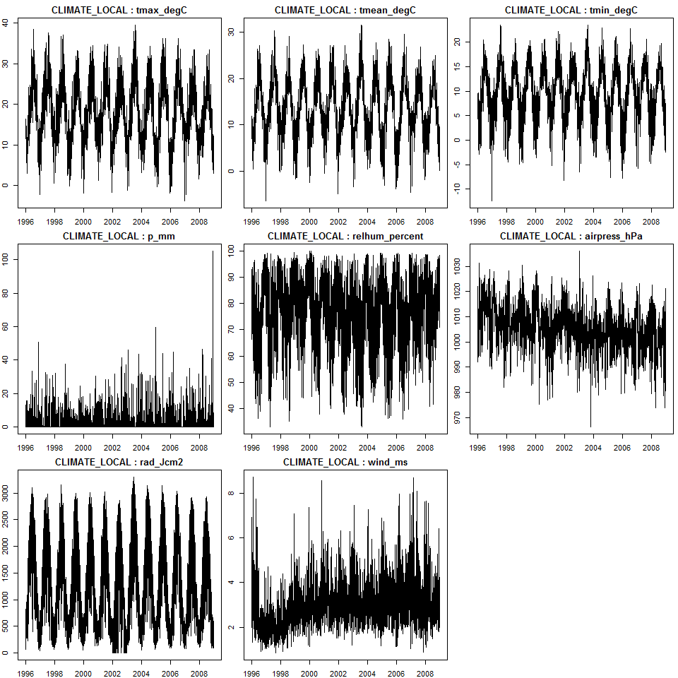

```r
plotData(dataset = "CLIMATE_LOCAL", site = "le_bray", automaticPanels = TRUE)
```

Or for TREE data

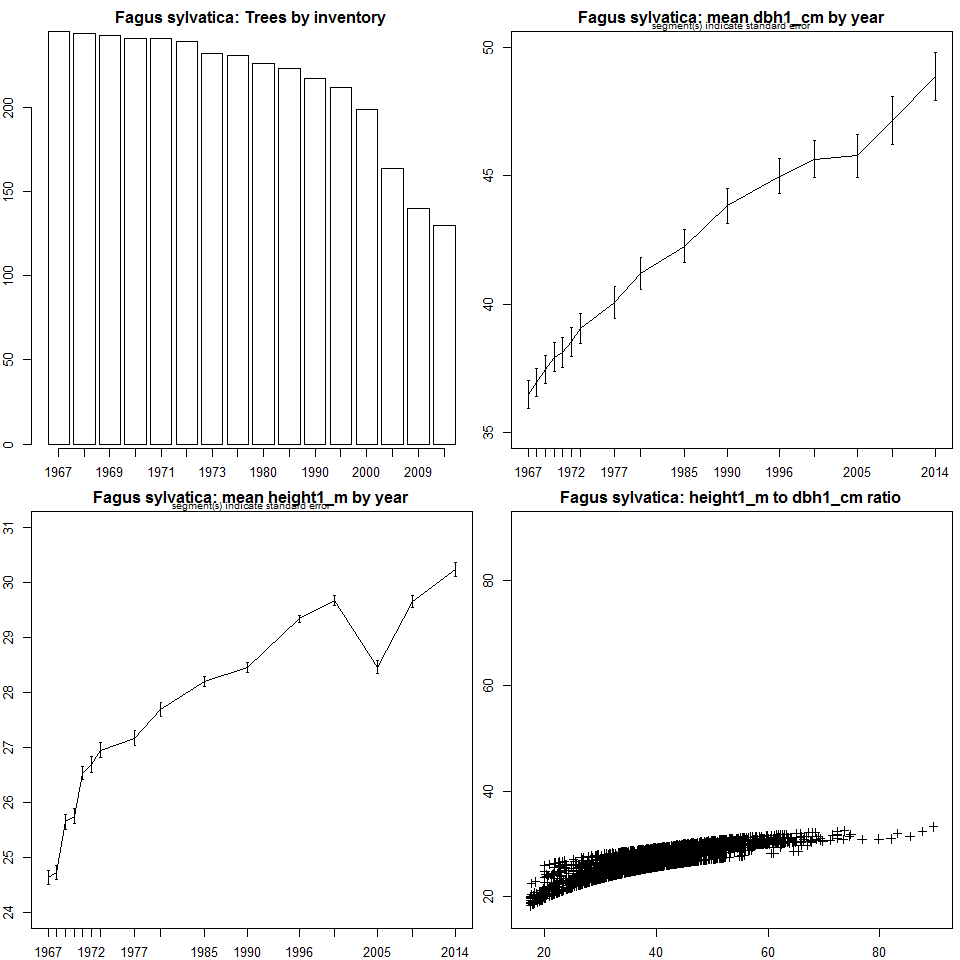

```r
plotData(dataset = "TREE", site = "solling_beech", automaticPanels = TRUE)
```

Note that the argument *automaticPanels* defines whether to plot in a panel.

## Additional options

Besides, plotData supports the same options as getData.

### forcingDataset, forcingCondition

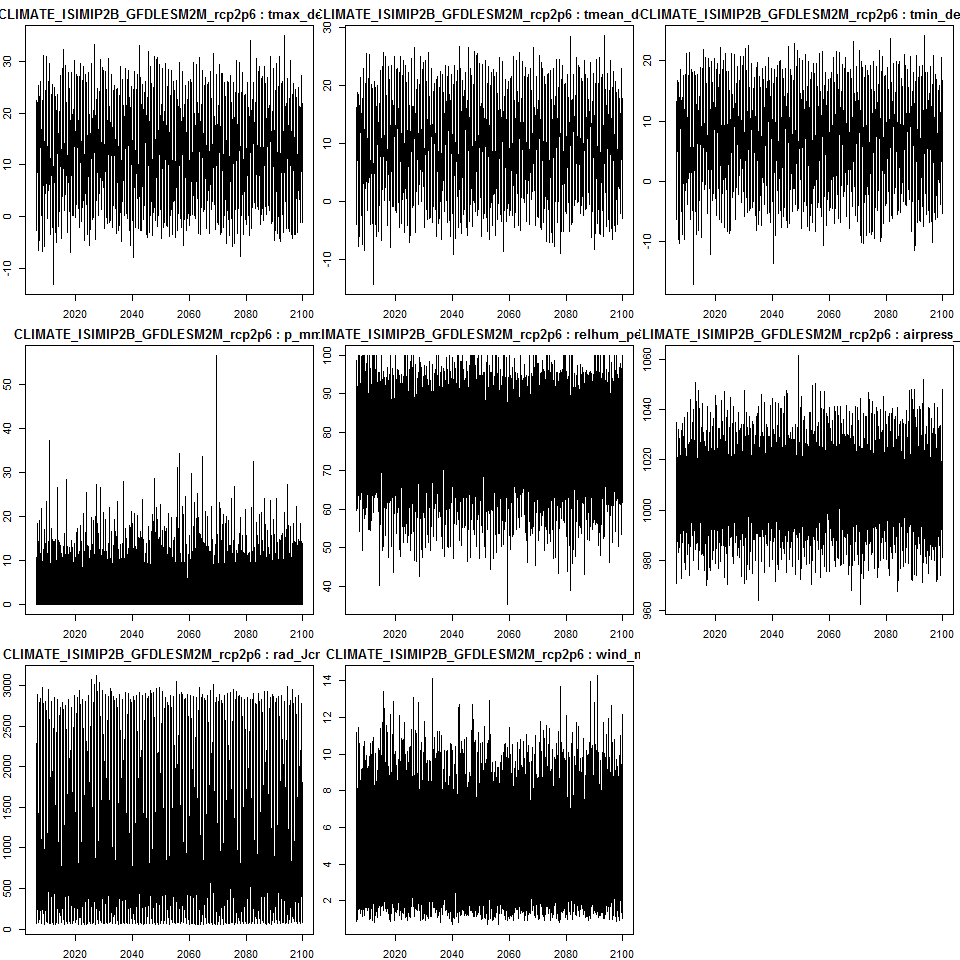

```r
plotData(dataset ="CLIMATE_ISIMIP2B", site ="soro",
         forcingDataset="GFDLESM2M", forcingCondition ="rcp2p6",
         automaticPanels = TRUE)
```

### variables

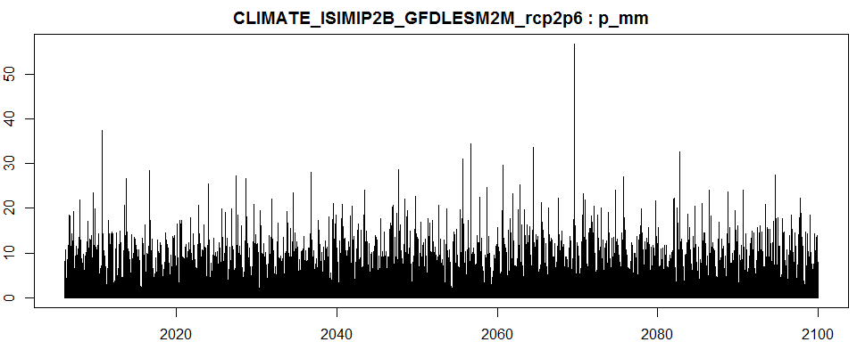

```r
plotData(dataset ="CLIMATE_ISIMIP2B",site ="soro",
         forcingDataset="GFDLESM2M", forcingCondition ="rcp2p6",
         variables = "p_mm")
```

### species

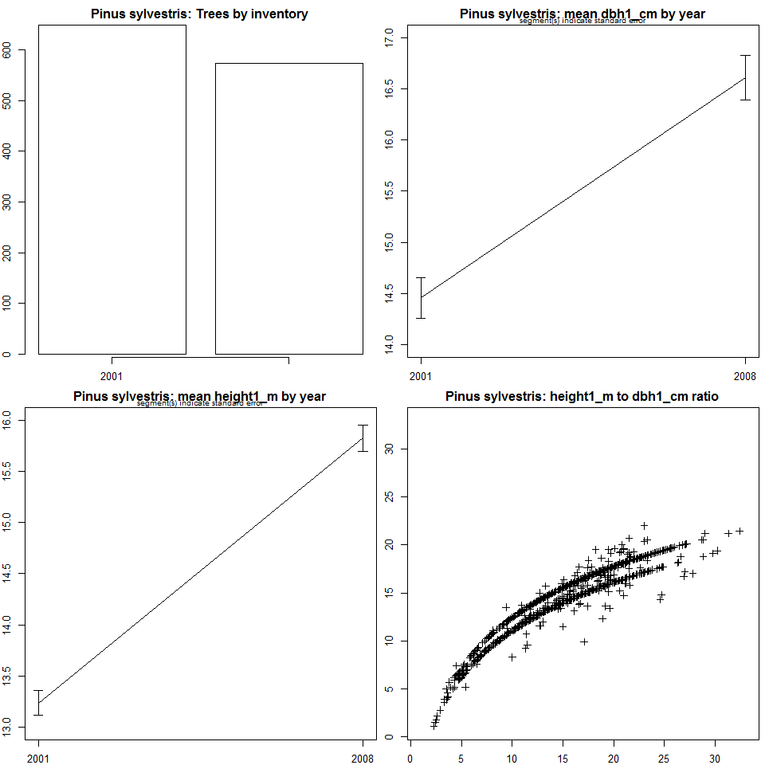

```r
plotData(dataset ="TREE", site ="hyytiala", species = "Pinus sylvestris",
         automaticPanels = TRUE)
```

### period

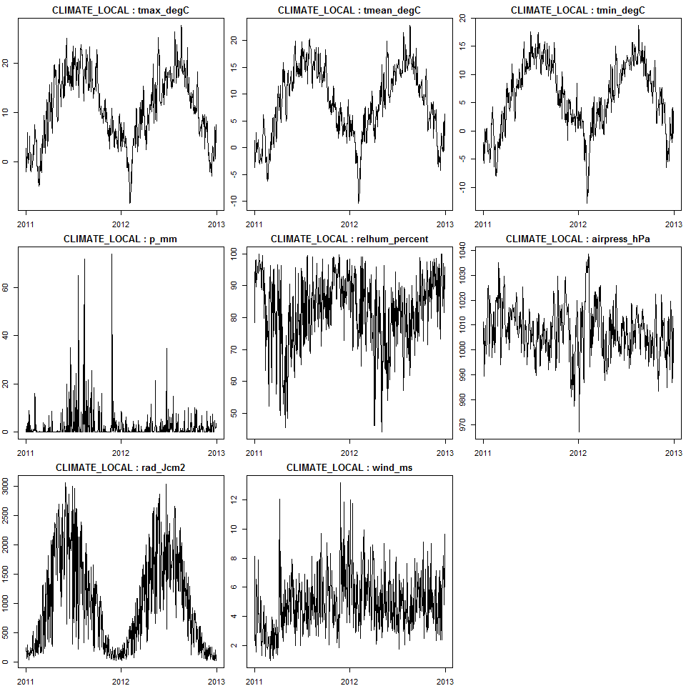

```r
plotData("CLIMATE_LOCAL", "soro", period = c("2011-01-01","2012-12-31"))
```

### quality

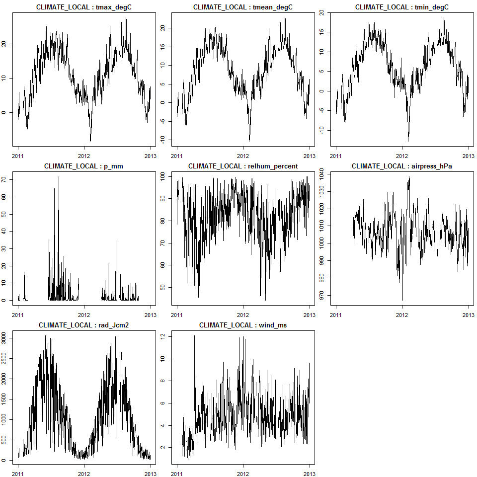

```r
plotData("CLIMATE_LOCAL", "soro", period = c("2011-01-01","2012-12-31"),
         quality = 1, decreasing = FALSE)
```

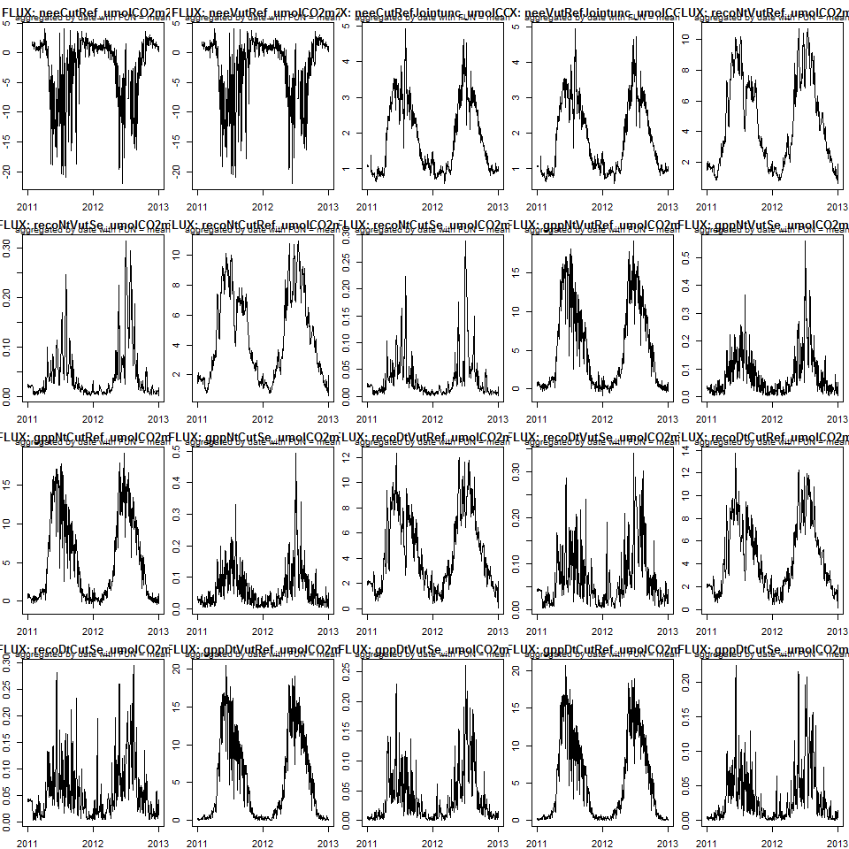

```r
plotData("FLUX", "soro", period = c("2011-01-01","2012-12-31"),
         quality = 0, decreasing = TRUE)
```

### aggregate

You can also aggregate data by defining *aggregate* and *FUN*. The data can be aggregated by day, month, year or date, and any statistic is supported, e.g. median.

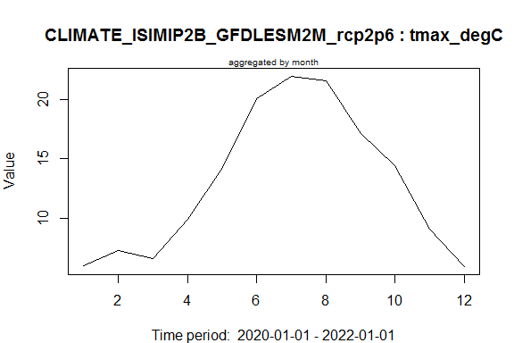

```r
plotData(dataset = "CLIMATE_ISIMIP2B", site ="soro",
         forcingDataset= "GFDLESM2M", forcingCondition="rcp2p6",
         variables = "tmax_degC", period = c("2020-01-01", "2022-01-01"),
         aggregate = "month", FUN =median, automaticPanels = FALSE)
```

# The queryDB function: parsing your own queries

The package functions are designed to ease the access to the PROFOUND database by providing an R interface. However, if you feel confident with SQL syntax’s, you could perform more advanced queries. The function *queryDB* allows to perform self-defined queries.

A basic query is *SELECT* FROM TABLE*, which will return all variables in the table.

```r
overview <- queryDB("SELECT * FROM OVERVIEW")
tree <- queryDB("SELECT * FROM TREE")
```

More advanced queries include defining variables and conditions as the example below

```r
myQuery <- queryDB("SELECT date, tmax_degC FROM CLIMATE_LOCAL
                   WHERE tmax_degC > 20 AND site == 'hyytiala' AND year == 2010")
```

Besides, the database contains several views with ready-made queries (check *browseData(“DATASETS”)*), so that the two statements below are equivalent

```r
myQuery <- queryDB("SELECT date, tmax_degC FROM CLIMATE_LOCAL
                   WHERE site == 'hyytiala'")
myQuery <- queryDB("SELECT date, tmax_degC FROM CLIMATE_LOCAL_12")
```

This also works with tree species

```r
myQuery <- queryDB("SELECT * FROM TREE
                   WHERE species == 'Picea abies'")
myQuery <- queryDB("SELECT * FROM TREE_piab")
```

Hint: Check the last section for further information about SQL syntax’s.

# The reportDB function

This function permits creating a site-by-site report of all avalaible data in the PROFOUND database. The summary is created with a rmarkdown document, which is rendered and saved as a html document. The report provides an exhaustive description and visualization of the PROFOUND database.

The function requires a path where to save the html document. If no path is specified, the working directory will be used as output directory.

```r
reportDB(outDir = tempdir())
```

Please note that creating the report might take several minutes.

# Using the database via sql

To access the database you can use an SQLite database explorer such as [SQLiteStudio](http://sqlitestudio.pl/). Such software allows to visualize and download data through an interface, as well as writing SQL statements. Further information on SQLite characteristics can be found on the [SQLite website](https://www.sqlite.org/lang.html). Besides, there are plenty of resources about using SQL like [this one](http://www.w3schools.com/sql/default.asp)